# Simple Linear Regression Assignment

eidhne kennedy, id=21347021

28 November, 2022

## Predicting 3 km Running Times based on laboratory testing.

### Study Description:

Sixteen well-trained male middle and long distance runners performed a 3 km time trial and a number of running tests in the laboratory including their running velocity at a blood lactate concentration of 4 mmol.l-1 (v4mM). Other variables measured were running velocity at their Lactate Threshold (vTlac), and VO2 max. All the laboratory testing took place on a motorised treadmill, and distance running performance was determined by 3 km time trials on an indoor 200m track.

### Aims:

To investigate whether there is we can use linear regression to predict 3 km running time (minutes) from v-4mM (km per hour) in the population of well-trained male middle and long distance runners. Hence to predict 3km running time using running velocity at blood lactate concentration 4 mmol per litre.

- Response Variable: 3km running time (`Running.Time`) measured in minutes
- Explanatory Variable: running velocity at blood lactate concentration at 4mmol per litre (`v4mM`) measured in km/hr

```r
library(tidyverse)
```

### Read the data and see a few rows

```r
running = read.csv("3krunning.csv", header = TRUE)
head(running)
```

```
##   Running.Time v4mM vTlac Rel.14.5 Rel.16.1 VO2Max
## 1         8.23 20.4  19.5     47.1     52.4   23.4
## 2         8.30 19.5  18.2     48.1     60.0   23.5
## 3         8.62 19.0  17.3     50.3     56.8   22.0
## 4         8.82 18.9  17.8     51.8     56.1   23.0
## 5         9.18 17.8  16.5     48.7     54.1   21.5
## 6         9.23 17.2  15.6     50.5     59.6   20.5
```

### Summary Statistics

Task: Calculate the summary statistics for each column in the data and describe the key features of the data.

```r
running %>%
  summarize(Mean.Time = mean(Running.Time),
            SD.Time = sd(Running.Time),
            Mean.v4mM = mean(v4mM),
            SD.v4mM = sd(v4mM),
            Mean.vTlac = mean(vTlac),
            SD.vTlac = sd(vTlac),
            Mean.Rel.14.5 = mean(Rel.14.5),
            SD.Rel.14.5 = sd(Rel.14.5),
            Mean.Rel.16.1 = mean(Rel.16.1),
            SD.Rel.16.1 = sd(Rel.16.1),
            Mean.VO2Max = mean(VO2Max),
            SD.VO2Max = sd(VO2Max))
```

```
##   Mean.Time  SD.Time Mean.v4mM  SD.v4mM Mean.vTlac SD.vTlac Mean.Rel.14.5
## 1  9.458125 0.744269  17.06875 1.848141      15.95 1.775763      51.59375
##   SD.Rel.14.5 Mean.Rel.16.1 SD.Rel.16.1 Mean.VO2Max SD.VO2Max
## 1    3.289877      57.81875    3.775221     20.6875  2.133503
```

The standard deviation of running time is less than a minute, which should be noted when trying to make any predictions about the running times, as predictions will seem more accurate than they are due to the relative closeness of the sample times. The velocity at blood lactate concentration 4 mmol/litre, however, has a much broader relative standard deviation, which should also be noted.

Another point of note is that these runners are trained for middle- and long-distance running, so there may be a large discrepancy in values like VO2 max, given the specialty of the individual runner and the differences in fitness required for each discipline.

### Scatterplot

Task: Make a labelled scatterplot of `v4mM` vs `Running.Time` and interpret it.

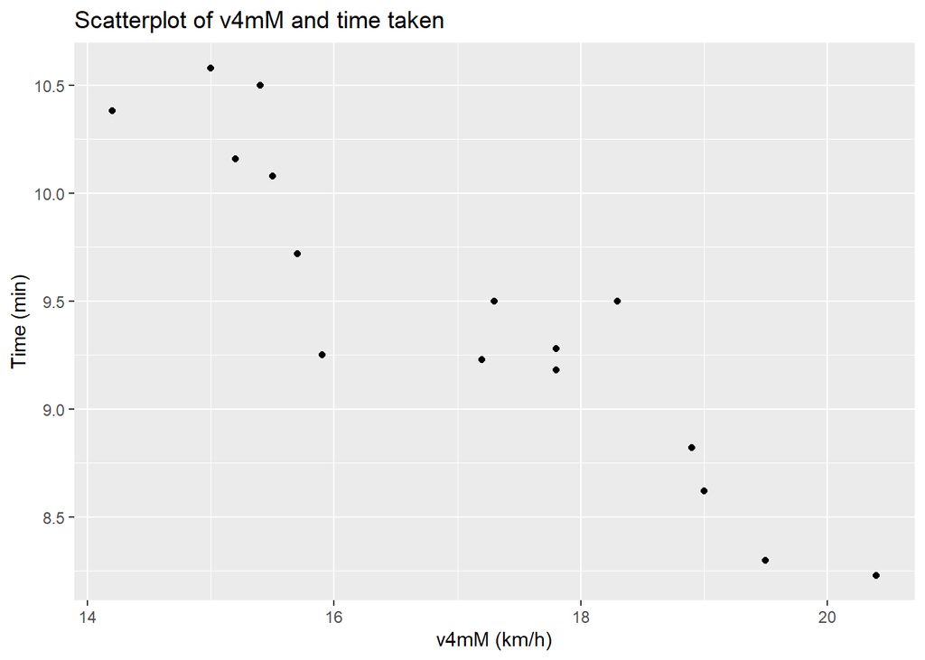

```r
ggplot(running, aes(x = v4mM, y = Running.Time)) +
  geom_point() +
  labs(x = "v4mM (km/h)", y = "Time (min)",
       title = "Scatterplot of v4mM and time taken")
```

There seems to be a linear, inverse correlation between v4mM and time taken, and there seem to be a few outliers, but it is unclear by eye.

### Scatterplot with smoother.

Task: Add a smooth line to the scatter plot produced in the previous task, and include the new plot below.

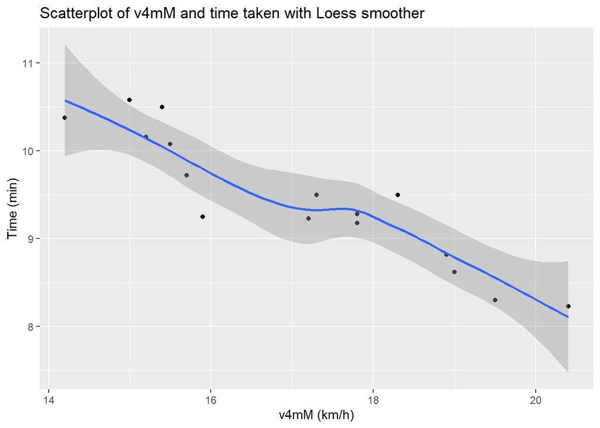

```r
ggplot(running, aes(x = v4mM, y = Running.Time)) +
  geom_point() +
  geom_smooth() +
  labs(x = "v4mM (km/h)", y = "Time (min)",
       title = "Scatterplot of v4mM and time taken with Loess smoother")
```

Task: What does the smoother suggest regarding the suitability of a simple linear regression model for this relationship?

The smoother appears to agree with my previous assessment, that there is a clear linear, inverse relationship between these two variables.

### Correlation coefficient

Task: calculate the correlation coefficient between `v4mM` vs `Running.Time` and interpret it.

```r
running %>% select (v4mM, Running.Time) %>% cor()
```

```
##                   v4mM Running.Time
## v4mM          1.000000    -0.925857
## Running.Time -0.925857     1.000000
```

The correlation is very close to -1, therefore there exists a strong inverse correlation between these two variables, as evidenced in the prior scatterplots.

It should be noted, in the face of a correlation this strong, that correlation does not imply causation.